# xwMOOC 네트워크

네트워크 데이터

## 1. 네트워크 데이터 구조

기본적인 네트워크 데이터 표현 형식은 다음과 같은 **사회행렬(SocioMatrix)** 자료구조를 갖는다.

|  | A | B | C | D | E |
| --- | --- | --- | --- | --- | --- |
| A | 0 | 1 | 1 | 0 | 0 |
| B | 0 | 0 | 1 | 1 | 0 |
| C | 0 | 1 | 0 | 0 | 0 |
| D | 0 | 0 | 0 | 0 | 0 |
| E | 0 | 0 | 1 | 0 | 0 |

즉 각 노드간에 관계가 있냐 없냐를 없으면 `0`, 연결관계가 있다면 `1`로 표현한다. 하지만, 이와 같이 표현을 하게 되면 네트워크가 큰 경우 거의 대부분의 관계가 `0`으로 없음에도 불구하고 이를 사회행렬로 표현하게 되어, 저장공간 낭비가 엄청 심하게 된다.

노드가 10, 100, 1000 이며, 평균 연결수가 3 인 경우 1000개 노드를 갖는 네트워크를 사회행렬로 표현할 경우 997,000 개의 빈셀을 갖게 된다. 이런 이유로 **엣지리스트(Edgelist)** 로 네트워크를 데이터로 표현할 경우 동일한 네트워크를 효과적으로 표현할 수 있다.

| 노드 | 평균 연결수 | 엣지 | 밀도 | 빈셀 |
| --- | --- | --- | --- | --- |
| 10 | 3 | 15 | 0.33 | 70 |
| 100 | 3 | 150 | 0.03 | 9,700 |
| 1,000 | 3 | 1,500 | 0.00 | 997,000 |

상기 사회행렬을 엣지리스트로 표현하면 다음과 같다. 소규모 네트워크에서는 데이터에 큰 차이가 없지만, 중소규모, 대규모로 네트워크 규모가 커지면 네트워크 표현에 대한 효과를 체험하게 된다.

| From | To |
| --- | --- |
| A | B |
| A | C |
| B | C |
| B | D |
| C | B |
| E | C |

### 1.1. 네트워크 객체에 저장되는 정보

노드와 엣지는 네트워크 자료형으로 꼭 필요하지만, 추가적인 정보를 더 담을 수 있고, 담아야 한다. 노드와 엣지 외에도 노드 속성, 엣지 속성, 네트워크 메타데이터가 네트워크 자료형을 구성하고 있다.

| 구성요소 | 설명 | 필수여부 |
| --- | --- | --- |
| 노드 | 노드 혹은 `Vertex`라고 불리며 네트워크 노드를 구성 | 필수 |
| 엣지 | 엣지 혹은 링크, `Tie`라고 불리며 네트워크 연결을 담당 | 필수 |
| 노드 속성 | 노드 속성을 표현, 노드가 사람인 경우 성별 등 | 선택옵션 |
| 엣지 속성 | 엣지 속성을 표현, 엣지가 금융거래의 경우 거래금액 등 | 선택옵션 |
| 메타데이터 | 전체 네트워크에 대한 정보를 포함 | 네트워크에 따라 다름 |

### 1.2. `statnet` 네트워크 자료형

#### 1.2.1. `statnet` 네트워크 객체 생성 – 사회행렬

`statnet` 팩키지에서 네트워크 노드는 Vertex라고 부른다. `network` 함수를 사용해서 네트워크 객체를 생성하게 된다. `matrix.type="adjacency"`으로 설정하여 사회행렬 자료 구조를 R 네트워크 자료구조로 변환시킨다.

```r
suppressWarnings(suppressMessages(library(network)))
# 1. 사회행렬(Sociomatrix)
netmat1 <- rbind(c(0,1,1,0,0),
                 c(0,0,1,1,0),
                 c(0,1,0,0,0),
                 c(0,0,0,0,0),
                 c(0,0,1,0,0))
rownames(netmat1) <- c("A","B","C","D","E")
colnames(netmat1) <- c("A","B","C","D","E")
net1 <- network(netmat1, matrix.type="adjacency")
class(net1)
```

```
[1] "network"
```

```r
summary(net1)
```

```
Network attributes:
  vertices = 5
  directed = TRUE
  hyper = FALSE
  loops = FALSE
  multiple = FALSE
  bipartite = FALSE
 total edges = 6
   missing edges = 0
   non-missing edges = 6
 density = 0.3

Vertex attributes:
  vertex.names:
   character valued attribute
   5 valid vertex names

No edge attributes

Network adjacency matrix:
  A B C D E
A 0 1 1 0 0
B 0 0 1 1 0
C 0 1 0 0 0
D 0 0 0 0 0
E 0 0 1 0 0
```

`class()`, `summary()` 함수를 통해 자료형과 더불어 전반적인 사항에 대한 확인이 가능하다.

#### 1.2.2. `statnet` 네트워크 객체 생성 – 엣지리스트

동일한 네트워크를 엣지리스트로 표현이 가능하다. `matrix.type="edgelist"`으로 설정하여 엣지리스트 자료 구조를 R 네트워크 자료구조로 변환시킨다. 특히, `network.vertex.names()` 함수를 통해 엣지리스트 자료형의 경우 라벨을 붙인다.

```r
suppressWarnings(suppressMessages(library(sna)))
# 2. 엣지리스트(Edgelist)

netmat2 <- rbind(c(1,2),
                 c(1,3),
                 c(2,3),
                 c(2,4),
                 c(3,2),
                 c(5,3))
net2 <- network(netmat2,matrix.type="edgelist")
network.vertex.names(net2) <- c("A","B","C","D","E")
class(net2)
```

```
[1] "network"
```

```r
summary(net2)
```

```
Network attributes:
  vertices = 5
  directed = TRUE
  hyper = FALSE
  loops = FALSE
  multiple = FALSE
  bipartite = FALSE
 total edges = 6
   missing edges = 0
   non-missing edges = 6
 density = 0.3

Vertex attributes:
  vertex.names:
   character valued attribute
   5 valid vertex names

No edge attributes

Network adjacency matrix:
  A B C D E
A 0 1 1 0 0
B 0 0 1 1 0
C 0 1 0 0 0
D 0 0 0 0 0
E 0 0 1 0 0
```

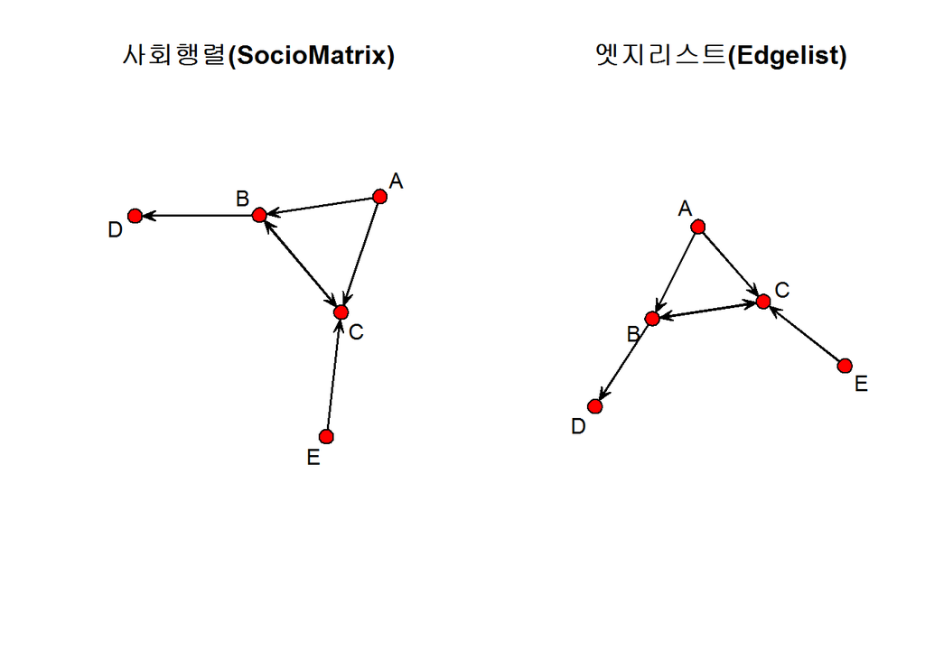

```r
# 시각화
par(mfrow=c(1,2))
gplot(net1, vertex.col = 2, displaylabels = TRUE, main="사회행렬(SocioMatrix)")
gplot(net2, vertex.col = 2, displaylabels = TRUE, main="엣지리스트(Edgelist)")
```

#### 1.2.3. `statnet` 네트워크 조작

노드에 속성을 내외부에서 추가하고 이를 조회하는 것도 가능하다.

`set.vertex.attribute()` 함수를 통해 외부에서 노드에 대한 속성(`gender`)을 추가하고, 내부에서도 `degree()` 속성(`alldeg`) 추가도 가능하다. 네트워크 노드에 대한 속성은 `list.vertex.attributes()` 함수로 확인이 가능하다.

```r
# 1. 노드 속성
set.vertex.attribute(net1, "gender", c("F", "F", "M", "F", "M"))
net1 %v% "alldeg" <- degree(net1)
list.vertex.attributes(net1)
```

```
[1] "alldeg"       "gender"       "na"           "vertex.names"
```

```r
get.vertex.attribute(net1, "gender")
```

```
[1] "F" "F" "M" "F" "M"
```

`set.edge.attribute()` 함수를 통해 엣지에 속성(`rndval`) 추가가 가능하다. 나머지 `list.edge.attributes()` 함수를 통해 엣지에 추가된 속성 확인을 한다.

```r
# 2. 엣지 속성
list.edge.attributes(net1)
```

```
[1] "na"
```

```r
set.edge.attribute(net1,"rndval", runif(network.size(net1),0,1))
list.edge.attributes(net1)
```

```
[1] "na"     "rndval"
```

```r
summary(net1 %e% "rndval")
```

```
   Min. 1st Qu.  Median    Mean 3rd Qu.    Max.
 0.1197  0.5813  0.6110  0.5821  0.7055  0.8427
```

```r
summary(get.edge.attribute(net1,"rndval"))
```

```
   Min. 1st Qu.  Median    Mean 3rd Qu.    Max.
 0.1197  0.5813  0.6110  0.5821  0.7055  0.8427
```

엣지속성은 SNS같은 네트워크를 표현할 때 자주 등장한다. 다음과 같은 SNS에서 `좋아요(like)`를 표현할 때 요긴한데, ignore.eval=FALSE, names.eval=“like” 인자로 표현하게 되면 네트워크 엣지에 0, 1 대신 실제 값(좋아요 갯수) 사용이 가능하다.

```r
netval1 <- rbind(c(0,2,3,0,0),
c(0,0,3,1,0),
c(0,1,0,0,0),
c(0,0,0,0,0),
c(0,0,2,0,0))
netval1 <- network(netval1,matrix.type="adjacency", ignore.eval=FALSE,names.eval="like")
network.vertex.names(netval1) <- c("A","B","C","D","E")
list.edge.attributes(netval1)
```

```
[1] "like" "na"
```

```r
get.edge.attribute(netval1, "like")
```

```
[1] 2 1 3 3 2 1
```

`as.sociomatrix(netval1)`, `as.sociomatrix(netval1,"like")` 를 통해 사회행렬에 표현되는 방식을 달리할 수 있다.

### 1.3. `igraph` 네트워크 자료형 [^1]

네트워크 객체를 R에서 표현하는 또다른 방법이 `igraph`를 활용하는 것이다. igraph 네트워크 객체로 표현하면 노드속성과 엣지속성을 표현하는데 편리한 장점이 있다.

`igraph` 팩키지에 내장된 `graph()` 함수에 `edges=`, `n=` 인자를 넣어 네트워크 자료형을 생성한다. 인자명에 나타나듯이 `edges=`는 엣지를, `n=`는 노드를 표현한다.

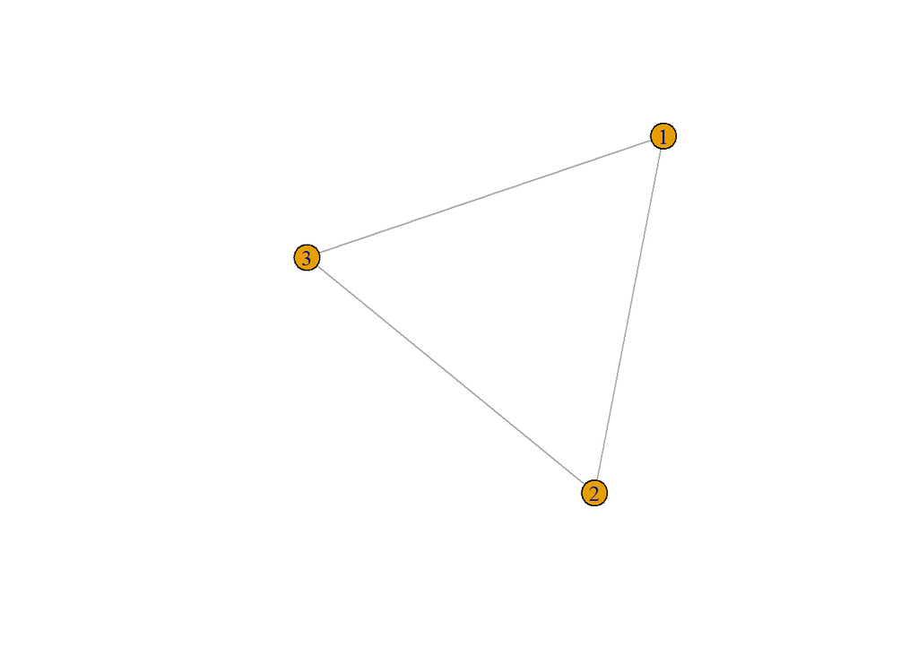

```r
suppressWarnings(suppressMessages(library(igraph)))
#---------------------------------------------------------------------------------
# 01. 네트워크 생성 기초
#---------------------------------------------------------------------------------
# 그래프1
g1 <- graph( edges=c(1,2, 2,3, 3,1), n=3, directed=FALSE)
plot(g1)
```

```r
class(g1)
```

```
[1] "igraph"
```

```r
g1
```

```
IGRAPH 2857d94 U--- 3 3 --
+ edges from 2857d94:
[1] 1--2 2--3 1--3
```

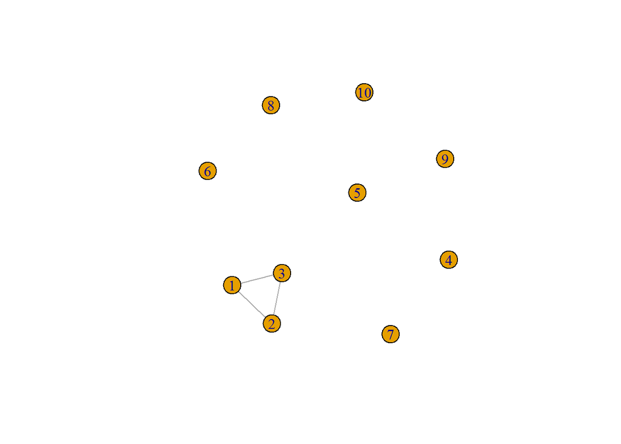

```r
# 그래프2
g2 <- graph( edges=c(1,2, 2,3, 3,1), n=10, directed=FALSE)
plot(g2)
```

```r
g2
```

```
IGRAPH 285b82e U--- 10 3 --
+ edges from 285b82e:
[1] 1--2 2--3 1--3
```

노드간 번호를 연결하는 대신에 노드명칭으로 노드를 연결하는 것도 가능하다.

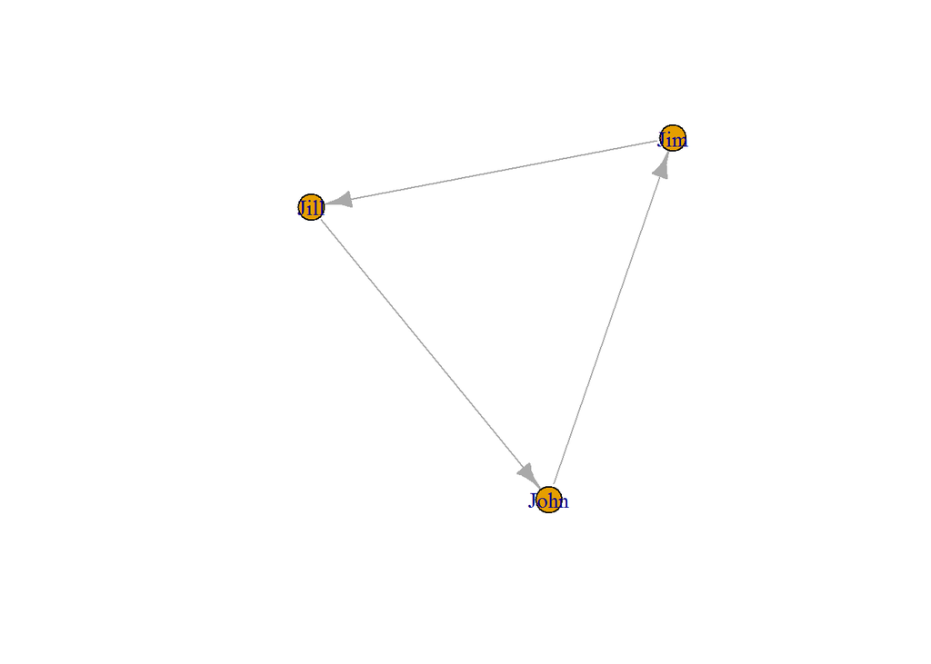

```r
# 그래프3
g3 <- graph( edges=c("John","Jim", "Jim","Jill", "Jill", "John"))
plot(g3)
```

```r
g3
```

```
IGRAPH 28dceb3 DN-- 3 3 --
+ attr: name (v/c)
+ edges from 28dceb3 (vertex names):
[1] John->Jim  Jim ->Jill Jill->John
```

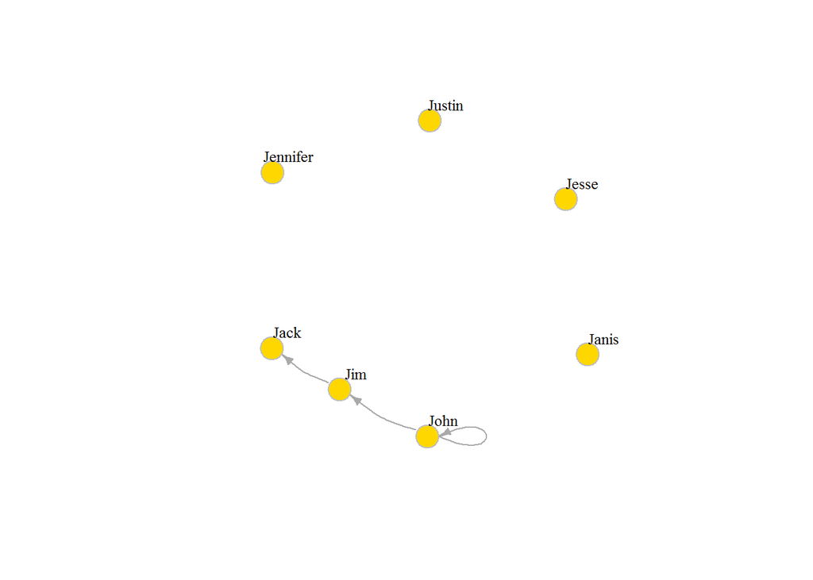

```r
# 그래프4
g4 <- graph( c("John", "Jim", "Jim", "Jack", "Jim", "Jack", "John", "John"),
             isolates=c("Jesse", "Janis", "Jennifer", "Justin") )

plot(g4, edge.arrow.size=.5, vertex.color="gold", vertex.size=15,
     vertex.frame.color="gray", vertex.label.color="black",
     vertex.label.cex=0.8, vertex.label.dist=2, edge.curved=0.2)
```

`+`, `-`, `:` 기호를 활용하여 네트워크를 생성하는 것도 가능하다.

- - : 방향성 없음
- +-, -+ : 왼쪽, 오른쪽 방향 화살표
- ++ : 대칭 연결
- : 노드 집합(Sets of Vertices)

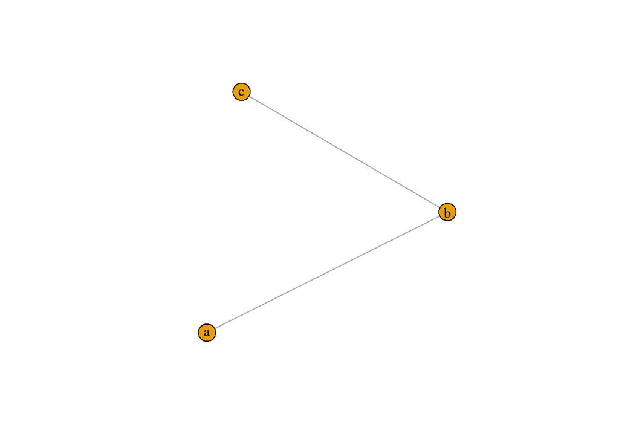

```r
#---------------------------------------------------------------------------------
# 02. 단순기호 활용 그래프 생성
#---------------------------------------------------------------------------------

# - 사례
plot(graph_from_literal(a---b, b---c))
```

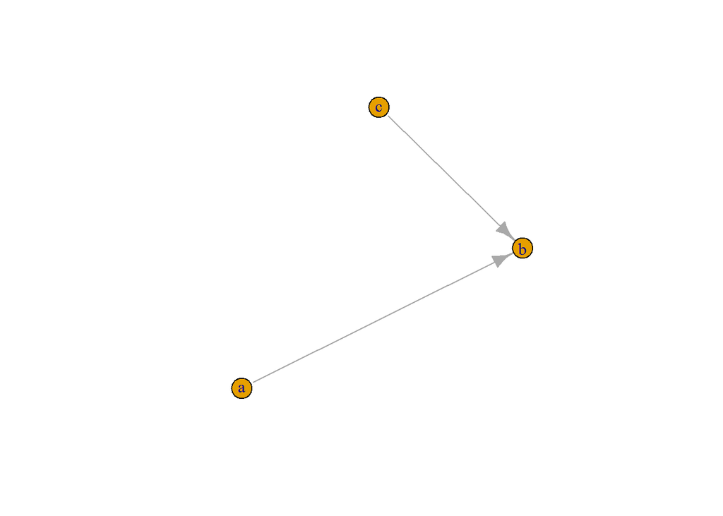

```r
# +-, -+ 사례
plot(graph_from_literal(a--+b, b+--c))
```

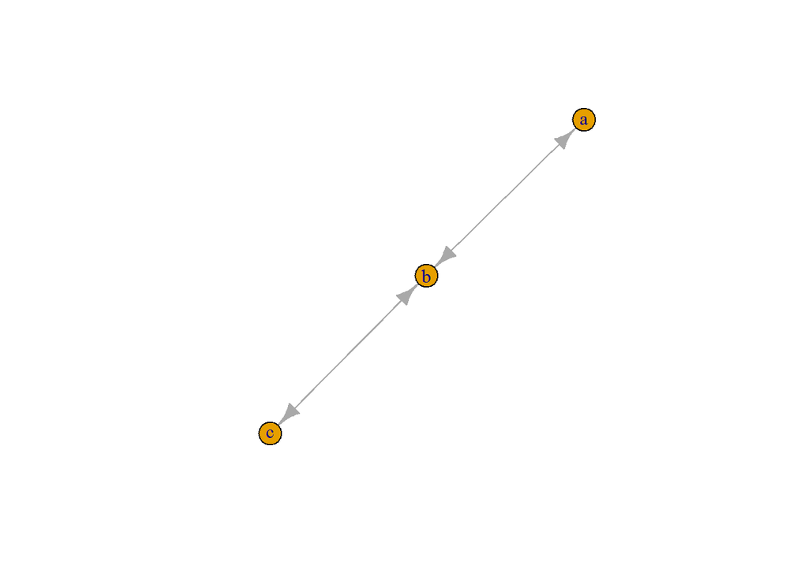

```r
# +-+ 대칭 사례
plot(graph_from_literal(a+-+b, b+-+c))
```

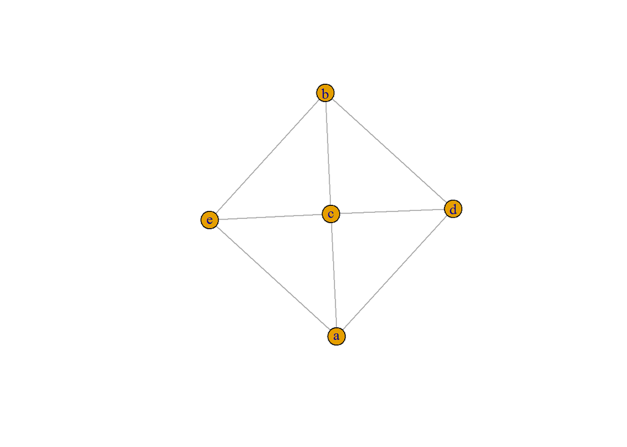

```r
# : 노드 집합(Sets of Vertices)
plot(graph_from_literal(a:b:c---c:d:e))
```

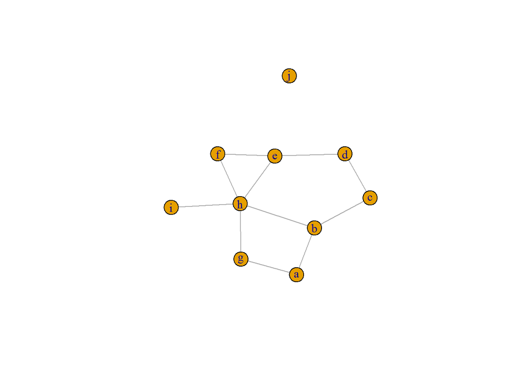

```r
# 종합 사례
gl <- graph_from_literal(a-b-c-d-e-f, a-g-h-b, h-e:f:i, j)
plot(gl)
```

#### 1.3.1 `igraph` 네트워크 엣지, 노드 속성 조작

사회행렬을 igraph 네트워크 객체로 가져오는데 `graph.adjacency()` 함수를 사용한다. 엣지리스트는 `graph.edgelist()` 함수를 사용한다.

특히, `V()`, `E()` 함수를 사용해서 노드와 엣지의 속성을 쉽게 부여한다.

```r
# detach(package:statnet)
suppressWarnings(suppressMessages(library(igraph)))

# 사회행렬 igraph 전환
inet1 <- graph.adjacency(netmat1)
class(inet1)
```

```
[1] "igraph"
```

```r
#summary(inet1)
#str(inet1)

# 엣지리스트 igraph 전환
inet2 <- graph.edgelist(netmat2)
#summary(inet2)
#str(inet2)

# 노드와 엣지 속성 부여
V(inet2)$name <- c("A","B","C","D","E")
E(inet2)$val <- c(1:6)
#summary(inet2)
#str(inet2)
```

`g4[]` 명령어를 통해 전체 사회행렬을 확인한다. `V(g4)$gender`, `E(g4)$type` 명령어를 통해 노드와 엣지에 속성을 부여한다. `set_graph_attr()` 함수로 동일한 작업이 가능하다. 물론, `delete_graph_attr()` 함수로 속성을 제거하는 것도 가능하다.

`simplify()` 함수를 통해 루프 및 중복 제거 등 네트워크를 필요시 간략화한다.

```r
E(g4)
```

```
+ 4/4 edges from 28dff89 (vertex names):
[1] John->Jim  Jim ->Jack Jim ->Jack John->John
```

```r
V(g4)
```

```
+ 7/7 vertices, named, from 28dff89:
[1] John     Jim      Jack     Jesse    Janis    Jennifer Justin
```

```r
g4[]
```

```
7 x 7 sparse Matrix of class "dgCMatrix"
         John Jim Jack Jesse Janis Jennifer Justin
John        1   1    .     .     .        .      .
Jim         .   .    2     .     .        .      .
Jack        .   .    .     .     .        .      .
Jesse       .   .    .     .     .        .      .
Janis       .   .    .     .     .        .      .
Jennifer    .   .    .     .     .        .      .
Justin      .   .    .     .     .        .      .
```

```r
g4[1,]
```

```
    John      Jim     Jack    Jesse    Janis Jennifer   Justin
       1        1        0        0        0        0        0
```

```r
V(g4)$name
```

```
[1] "John"     "Jim"      "Jack"     "Jesse"    "Janis"    "Jennifer"
[7] "Justin"
```

```r
# 엣지, 노드 속성부여 방법 1
V(g4)$gender <- c("male", "male", "male", "male", "female", "female", "male")
E(g4)$type <- "email"
E(g4)$weight <- 10

edge_attr(g4)
```

```
$type
[1] "email" "email" "email" "email"

$weight
[1] 10 10 10 10
```

```r
vertex_attr(g4)
```

```
$name
[1] "John"     "Jim"      "Jack"     "Jesse"    "Janis"    "Jennifer"
[7] "Justin"

$gender
[1] "male"   "male"   "male"   "male"   "female" "female" "male"
```

```r
graph_attr(g4)
```

```
named list()
```

```r
# 엣지, 노드 속성부여 방법 2
g4 <- set_graph_attr(g4, "name", "Email Network")
g4 <- set_graph_attr(g4, "something", "A thing")
graph_attr_names(g4)
```

```
[1] "name"      "something"
```

```r
graph_attr(g4, "name")
```

```
[1] "Email Network"
```

```r
graph_attr(g4)
```

```
$name
[1] "Email Network"

$something
[1] "A thing"
```

```r
g4 <- delete_graph_attr(g4, "something")
graph_attr(g4)
```

```
$name
[1] "Email Network"
```

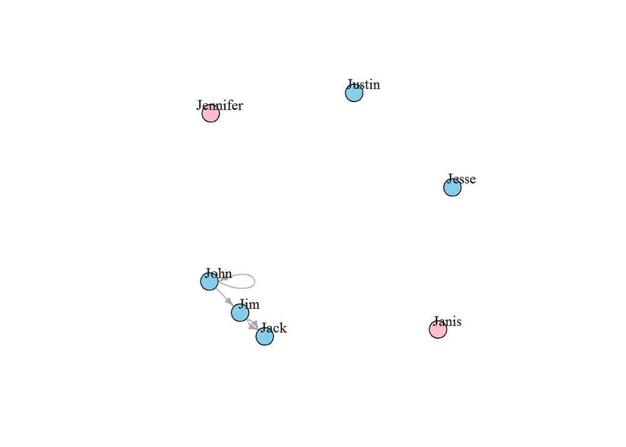

```r
# 시각화
plot(g4, edge.arrow.size=.5, vertex.label.color="black", vertex.label.dist=1.5,
     vertex.color=c( "pink", "skyblue")[1+(V(g4)$gender=="male")] )
```

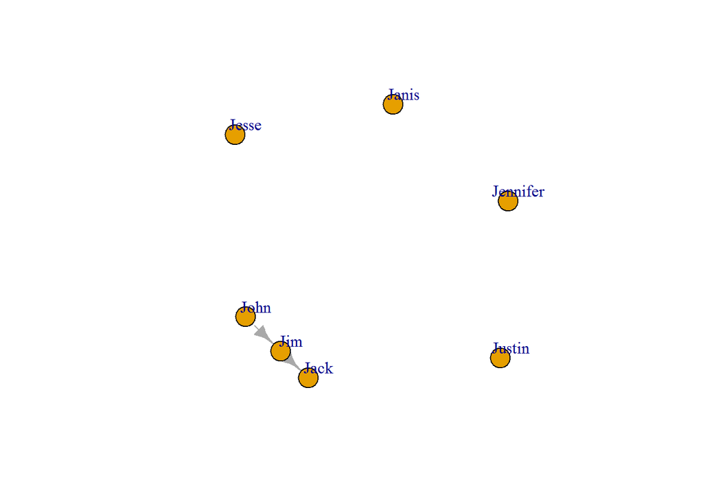

```r
# 간략화
g4s <- simplify( g4, remove.multiple = TRUE, remove.loops = TRUE,
                 edge.attr.comb=c(weight="sum", type="ignore") )
plot(g4s, vertex.label.dist=1.5)
```

### 1.4. `network`, `igraph` 네트워크 객체 전환

`network`와 `igraph` 네트워크 객체를 전환하는데 `intergraph` 팩키지를 사용한다.

```r
suppressWarnings(suppressMessages(library(intergraph)))
class(net1)
net1igraph <- asIgraph(net1)
class(net1igraph)
str(net1igraph)
```

[output not shown]

## 2. 네트워크 데이터 실무 사용례

네트워크 데이터는 **노드(Node)** 와 **엣지(Edge)** 로 구성된다. 노드 데이터는 네트워크 노드에 대한 상세 정보가 담겨있다. 반면에 엣지 정보는 연결된 링크 정보를 담고 있는데 `from`, `to` 형식으로 데이터를 담을 수도 있고, 노드간의 관계를 관계 없음은 `0`, 관계 있음은 `1`로 표현한다.

첫번째 네트워크 데이터 형식 표현을 **Edgelist** 라고 하고, 두번째 데이터 표현방법을 **사회행렬(SocioMatrix)** 이라고 부른다.

두가지 형태를 갖는 데이터를 불러 읽어오자.

```r
suppressMessages(library(readr))
suppressMessages(library(dplyr))
#-----------------------------------------------------------------------
# edgelist

nodes <- read_csv("https://raw.githubusercontent.com/kateto/R-Network-Visualization-Workshop/master/Data/Dataset1-Media-Example-NODES.csv", col_names = TRUE)
links <- read_csv("https://raw.githubusercontent.com/kateto/R-Network-Visualization-Workshop/master/Data/Dataset1-Media-Example-EDGES.csv", col_names = TRUE)

#-----------------------------------------------------------------------
# 행렬

nodes2 <- read_csv("https://raw.githubusercontent.com/kateto/R-Network-Visualization-Workshop/master/Data/Dataset2-Media-User-Example-NODES.csv", col_names = TRUE)
links2 <- read_csv("https://raw.githubusercontent.com/kateto/R-Network-Visualization-Workshop/master/Data/Dataset2-Media-User-Example-EDGES.csv", col_names = TRUE)

#-----------------------------------------------------------------------
# 데이터 살펴보기
#-----------------------------------------------------------------------

head(nodes)
```

```
# A tibble: 6 x 5
     id               media media.type type.label audience.size
  <chr>               <chr>      <int>      <chr>         <int>
1   s01            NY Times          1  Newspaper            20
2   s02     Washington Post          1  Newspaper            25
3   s03 Wall Street Journal          1  Newspaper            30
4   s04           USA Today          1  Newspaper            32
5   s05            LA Times          1  Newspaper            20
6   s06       New York Post          1  Newspaper            50
```

```r
head(links)
```

```
# A tibble: 6 x 4
   from    to weight      type
  <chr> <chr>  <int>     <chr>
1   s01   s02     10 hyperlink
2   s01   s02     12 hyperlink
3   s01   s03     22 hyperlink
4   s01   s04     21 hyperlink
5   s04   s11     22   mention
6   s05   s15     21   mention
```

```r
nrow(nodes); length(unique(nodes$id))
```

```
[1] 17
```

```
[1] 17
```

```r
nrow(links); nrow(unique(links[,c("from", "to")]))
```

```
[1] 52
```

```
[1] 49
```

```r
# 데이터 중복 처리 : 총합
links <- links %>% group_by(from, to, type) %>%
                   summarise(weight = sum(weight)) %>%
                   arrange(from, to)
```

`head(nodes)` 명령어를 통해서 살펴보면 `head(nodes2)`와 별다른 차이가 없다.

```r
head(nodes)
```

```
# A tibble: 6 x 5
     id               media media.type type.label audience.size
  <chr>               <chr>      <int>      <chr>         <int>
1   s01            NY Times          1  Newspaper            20
2   s02     Washington Post          1  Newspaper            25
3   s03 Wall Street Journal          1  Newspaper            30
4   s04           USA Today          1  Newspaper            32
5   s05            LA Times          1  Newspaper            20
6   s06       New York Post          1  Newspaper            50
```

```r
head(nodes2)
```

```
# A tibble: 6 x 5
     id   media media.type media.name audience.size
  <chr>   <chr>      <int>      <chr>         <int>
1   s01     NYT          1  Newspaper            20
2   s02    WaPo          1  Newspaper            25
3   s03     WSJ          1  Newspaper            30
4   s04    USAT          1  Newspaper            32
5   s05 LATimes          1  Newspaper            20
6   s06     CNN          2         TV            56
```

반면에 엣지 정보, 링크 정보는 하나는 `from`, `to` 형식으로, 다른 하나는 행렬로 표현된다는 점에서 차이가 있다.

```r
head(links)
```

```
# A tibble: 6 x 4
# Groups:   from, to [6]
   from    to      type weight
  <chr> <chr>     <chr>  <int>
1   s01   s02 hyperlink     22
2   s01   s03 hyperlink     22
3   s01   s04 hyperlink     21
4   s01   s15   mention     20
5   s02   s01 hyperlink     23
6   s02   s03 hyperlink     21
```

```r
head(links2)
```

```
# A tibble: 6 x 21
     X1   U01   U02   U03   U04   U05   U06   U07   U08   U09   U10   U11
  <chr> <int> <int> <int> <int> <int> <int> <int> <int> <int> <int> <int>
1   s01     1     1     1     0     0     0     0     0     0     0     0
2   s02     0     0     0     1     1     0     0     0     0     0     0
3   s03     0     0     0     0     0     1     1     1     1     0     0
4   s04     0     0     0     0     0     0     0     0     1     1     1
5   s05     0     0     0     0     0     0     0     0     0     0     1
6   s06     0     0     0     0     0     0     0     0     0     0     0
# ... with 9 more variables: U12 <int>, U13 <int>, U14 <int>, U15 <int>,
#   U16 <int>, U17 <int>, U18 <int>, U19 <int>, U20 <int>
```

*igraph* 팩키지로 데이터를 시각화를 해본다. 가장 먼저 노드와 엣지 데이터프레임을 [igraph](http://igraph.org/) 네트워크 객체로 변환해야 된다. `graph.data.frame` 함수가 노드와 엣지 데이터프레임 자료형을 igraph 네트워크 객체로 변환하는데 사용된다.

`graph.data.frame` 함수에 인자를 두개 넣는다.

- **d** : 네트워크 엣지(링크)를 넣어 넘긴다. `from`, `to` 형식으로 칼럼 두개가 먼저 정의되고, `weight`, `type`, `label` 등 엣지를 표현하는 다른 정보가 나머지 칼럼에 담기게 된다.
- **vertices** : 노드 id 로 첫번째 칼럼이 정의되고, 노드를 표현하는 다른 정보가 순차적으로 나머지 칼럼에 담기게 된다.

```r
suppressMessages(library(igraph))

net <- graph.data.frame(links, nodes, directed=T)
net
```

```
IGRAPH 2b713b8 DNW- 17 49 --
+ attr: name (v/c), media (v/c), media.type (v/n), type.label
| (v/c), audience.size (v/n), type (e/c), weight (e/n)
+ edges from 2b713b8 (vertex names):
 [1] s01->s02 s01->s03 s01->s04 s01->s15 s02->s01 s02->s03 s02->s09
 [8] s02->s10 s03->s01 s03->s04 s03->s05 s03->s08 s03->s10 s03->s11
[15] s03->s12 s04->s03 s04->s06 s04->s11 s04->s12 s04->s17 s05->s01
[22] s05->s02 s05->s09 s05->s15 s06->s06 s06->s16 s06->s17 s07->s03
[29] s07->s08 s07->s10 s07->s14 s08->s03 s08->s07 s08->s09 s09->s10
[36] s10->s03 s12->s06 s12->s13 s12->s14 s13->s12 s13->s17 s14->s11
[43] s14->s13 s15->s01 s15->s04 s15->s06 s16->s06 s16->s17 s17->s04
```

- `IGRAPH DNW- 17 49 --` :
  - D 혹은 U : 방향성 있는 그래프 혹은 방향성 없는 그래프를 기술
  - N : 노드는 `name` 속성을 갖는 것을 기술
  - W : 가중값이 있는 그래프로 엣지는 `weight` 속성을 갖는 것을 기술
  - B : 이분(Bipartite, two-mode) 그래프로 `type` 속성을 갖는 것을 기술
  - 17 49 : 노드가 17, 엣지가 49 개가 그래프에 존재함을 기술
- `attr: name (v/c), media (v/c), media.type (v/n), type.label (v/c), audience.size (v/n), type (e/c), weight (e/n)` :
  - (g/c) : graph-level character attribute
  - (v/c) : vertex-level character attribute
  - (e/n) : edge-level numeric attribute
  - (e/c) : edge-level character attribute

`E()` 함수를 통해 네트워크 객체에 포함된 엣지 정보를 추출한다. `V()` 함수를 통해 네트워크 객체에 포함된 노드 정보를 추출한다. 직접 행렬 원소를 뽑아내는 것도 가능하다.

```r
#------------------------------------------------------------------------
# 네트워크 객체 조회

E(net)       # "net" 객체 엣지정보 조회
```

```
+ 49/49 edges from 2b713b8 (vertex names):
 [1] s01->s02 s01->s03 s01->s04 s01->s15 s02->s01 s02->s03 s02->s09
 [8] s02->s10 s03->s01 s03->s04 s03->s05 s03->s08 s03->s10 s03->s11
[15] s03->s12 s04->s03 s04->s06 s04->s11 s04->s12 s04->s17 s05->s01
[22] s05->s02 s05->s09 s05->s15 s06->s06 s06->s16 s06->s17 s07->s03
[29] s07->s08 s07->s10 s07->s14 s08->s03 s08->s07 s08->s09 s09->s10
[36] s10->s03 s12->s06 s12->s13 s12->s14 s13->s12 s13->s17 s14->s11
[43] s14->s13 s15->s01 s15->s04 s15->s06 s16->s06 s16->s17 s17->s04
```

```r
V(net)       # "net" 객체 노드정보 조회
```

```
+ 17/17 vertices, named, from 2b713b8:
 [1] s01 s02 s03 s04 s05 s06 s07 s08 s09 s10 s11 s12 s13 s14 s15 s16 s17
```

```r
E(net)$type  # 엣지 속성 "type"
```

```
 [1] "hyperlink" "hyperlink" "hyperlink" "mention"   "hyperlink"
 [6] "hyperlink" "hyperlink" "hyperlink" "hyperlink" "hyperlink"
[11] "hyperlink" "hyperlink" "mention"   "hyperlink" "hyperlink"
[16] "hyperlink" "mention"   "mention"   "hyperlink" "mention"
[21] "mention"   "hyperlink" "hyperlink" "mention"   "hyperlink"
[26] "hyperlink" "mention"   "mention"   "mention"   "hyperlink"
[31] "mention"   "hyperlink" "mention"   "mention"   "mention"
[36] "hyperlink" "mention"   "hyperlink" "mention"   "hyperlink"
[41] "mention"   "mention"   "mention"   "hyperlink" "hyperlink"
[46] "hyperlink" "hyperlink" "mention"   "hyperlink"
```

```r
V(net)$media # 노드 속성 "media"
```

```
 [1] "NY Times"            "Washington Post"     "Wall Street Journal"
 [4] "USA Today"           "LA Times"            "New York Post"
 [7] "CNN"                 "MSNBC"               "FOX News"
[10] "ABC"                 "BBC"                 "Yahoo News"
[13] "Google News"         "Reuters.com"         "NYTimes.com"
[16] "WashingtonPost.com"  "AOL.com"
```

## 3. 네트워크 객체 조작

네트워크 객체를 생성하고 나면, 데이터프레임 조작하듯이 다양한 작업을 네트워크 자료형에도 수행해야 한다. 가장 많이 사용하는 것 중 하나가 전체 네트워크에서 관심있는 네트워크만 추출하는 것이다. 또다른 많이 사용되는 네트워크 조작 사용례는 방향성을 갖는 네트워크를 방향성 없는 네트워크로 변환시키는 것이다.

### 3.1. 노드 속성에 따른 네트워크 추출

`get.inducedSubgraph()` 함수를 사용해서 노드가 여성인 것만 뽑아낼 수 있다. `%v%` 연산자로 노드 속성 `gender`가 여성(`F`)만 추출해서 네트워크를 구성한다.

```r
detach("package:igraph", unload=TRUE)
# 노드 속성에 따른 네트워크 추출
n1F <- get.inducedSubgraph(net1,
                           which(net1 %v% "gender" == "F"))
n1F[,]
```

```
  A B D
A 0 1 0
B 0 0 1
D 0 0 0
```

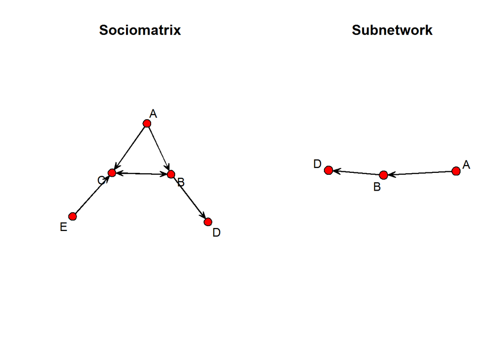

```r
par(mfrow=c(1,2))
gplot(net1, vertex.col = 2, displaylabels = TRUE, main="Sociomatrix")
gplot(n1F, displaylabels=TRUE, main="Subnetwork")
```

동일한 방식으로 네트워크 노드 속성 값에 따라 네트워크를 추출하는 것도 가능하다.

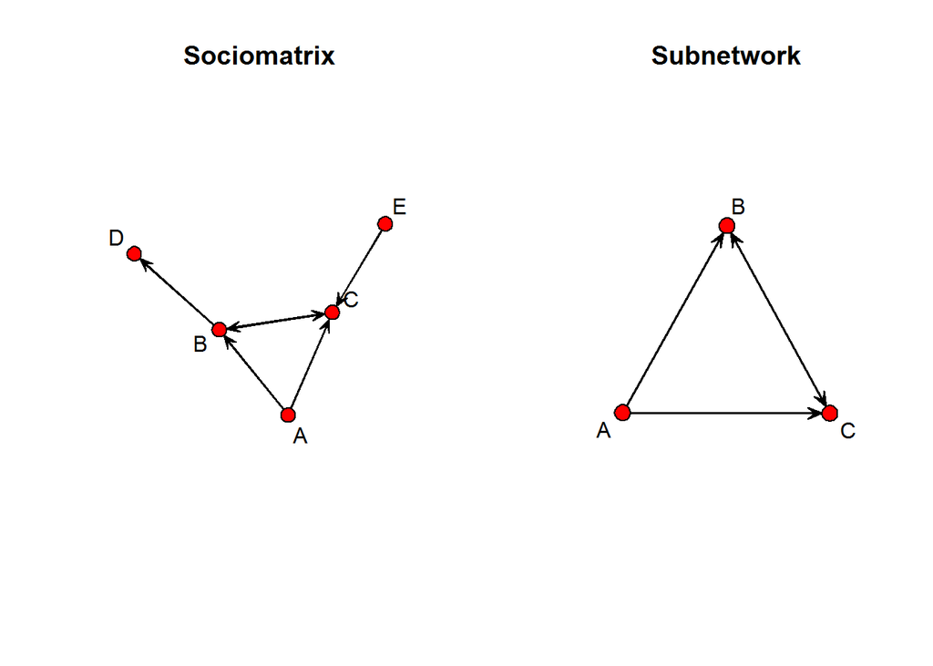

```r
# 노드 속성에 따른 네트워크 추출: 연결수(연속형)
deg <- net1 %v% "alldeg"
n2 <- net1 %s% which(deg > 1)

par(mfrow=c(1,2))
gplot(net1, vertex.col = 2, displaylabels = TRUE, main="Sociomatrix")
gplot(n2,displaylabels=TRUE, main="Subnetwork")
```

### 3.2. 고립된 노드 삭제

고립된 노드를 자동으로 삭제하는 것도 좀더 심도깊은 네트워크 분석을 위해서 필요하다.

`isolate` 함수를 통해 고립노드(연구원)을 식별해낸다. `delete.vertices()` 함수로 고립된 노드를 네트워크에서 제거한다.

```r
library(UserNetR)
data(ICTS_G10)

gden(ICTS_G10)
```

```
[1] 0.01120566
```

```r
length(isolates(ICTS_G10))
```

```
[1] 96
```

```r
n3 <- ICTS_G10
delete.vertices(n3,isolates(n3))
gden(n3)
```

```
[1] 0.01728876
```

```r
length(isolates(n3))
```

```
[1] 0
```

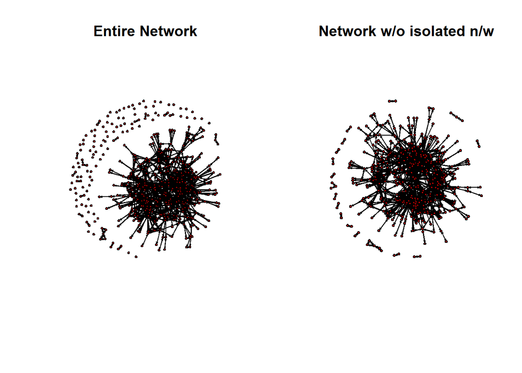

```r
par(mfrow=c(1,2))
gplot(ICTS_G10, vertex.col = 2, displaylabels = FALSE, main="Entire Network")
gplot(n3, displaylabels=FALSE, main="Network w/o isolated n/w")
```

### 3.3. 엣지 속성활용 네트워크 추출/단순화

엣지속성을 활용하여 네트워크 추출/단순화할 수 있다. 먼저 `network` 객체를 `igraph` 객체로 변환하여 기술통계를 살펴본다. `DHHS` 데이터셋은 11개 연구기관의 54명 전문가의 공동연구현황에 대한 네트워크 데이터다. `collab` 변수에는 4가지 연구 유형이 나와 있는데, 3,4번 즉 공동 프로젝트와 심도 깊은 다수 공동 프로젝트를 추진한 네트워크만 추출해서 살펴본다. 이유는 1,2,3,4번 협업 유형을 모두 시각화할 경우 너무 네트워크가 복잡해지기 때문이다. 이를 위해서 `igraph`가 전반적인 기술통계분석에 용이하다. 각자 편한 방법을 내재화하는 것도 좋을 듯 하다.

```r
# DHHS 네트워크 객체 기술통계분석
suppressWarnings(suppressMessages(library(igraph)))
suppressWarnings(suppressMessages(library(intergraph)))
data(DHHS)
class(DHHS)
```

```
[1] "network"
```

```r
DHHS_igraph <- intergraph::asIgraph(DHHS)
table(V(DHHS_igraph)$agency)
```

```
 0  1  2  3  4  5  6  7  8  9 10
 2  4 12  2  2  3  2 16  3  5  3
```

```r
table(E(DHHS_igraph)$collab)
```

```
  1   2   3   4
163 111  94  79
```

엣지 속성을 활용한 대략적인 하위 네트워크 추출 로직은 다음과 같다.

1. `as.sociomatrix` 함수로 `collab` 속성을 갖는 행렬을 추출한다.
2. 행렬 값이 1,2가 나온 것은 `0`으로 모두 채워넣는다.
3. `as.network` 함수로 필터된, 즉 3,4 번 연구유형만으로 네트워크를 새로 구성한다.

```r
# 3,4 번 유형만 추출
d <- DHHS
gden(d)
```

```
[1] 0.312369
```

```r
d.val <- as.sociomatrix(d, attrname="collab")
d.val[d.val < 3] <- 0
d.filt <- as.network(d.val, directed=FALSE,
                     matrix.type="a",ignore.eval=FALSE,
                     names.eval="collab")

gden(d.filt)
```

```
[1] 0.1208945
```

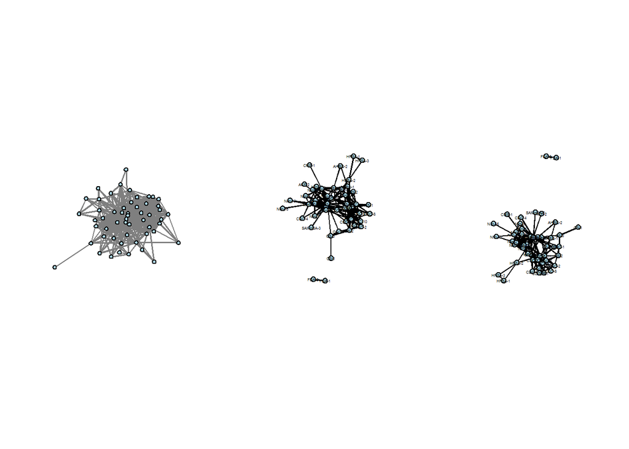

```r
# 시각화
par(mfrow=c(1,3))
gplot(DHHS,gmode="graph",edge.lwd=DHHS %e% 'collab',
      edge.col="grey50",vertex.col="lightblue",
      vertex.cex=1.0,vertex.sides=20)

gplot(d.filt,gmode="graph",displaylabels=TRUE,
      vertex.col="lightblue",vertex.cex=1.3,
      label.cex=0.4,label.pos=5,
      displayisolates=FALSE)

gplot(d.val,gmode="graph",thresh=2,displaylabels=TRUE,
      vertex.col="lightblue",vertex.cex=1.3,
      label.cex=0.4,label.pos=5,
      displayisolates=FALSE)
```

### 3.4. 방향성 있는 엣지를 방향성 없는 엣지로 변환

방향성 있는 엣지를 방향성 없는 엣지로 변환할 때는 `symmetrize`를 사용한다. 행렬 대각선을 따라 좌우 대칭이면 방향성 없는 엣지를 갖는 것으로 판단할 수 있다. `symmetrize` 함수를 실행하면 사회행렬이 반환되기 때문에 네트워크 자료형으로 변환작업이 추후 필요하다.

```r
#------------------------------------------------------------------------------
# 03. 방향성 없는 엣지를 방향성 있는 엣지로 변환
#------------------------------------------------------------------------------
# 방향성 없는 엣지로 변환
net1mat <- symmetrize(net1,rule="weak")
net1mat
```

```
     [,1] [,2] [,3] [,4] [,5]
[1,]    0    1    1    0    0
[2,]    1    0    1    1    0
[3,]    1    1    0    0    1
[4,]    0    1    0    0    0
[5,]    0    0    1    0    0
```

```r
# 네트워크 데이터 변환
net1symm <- network(net1mat,matrix.type="adjacency")
network.vertex.names(net1symm) <- c("A","B","C","D","E")
summary(net1symm)
```

```
Network attributes:
  vertices = 5
  directed = TRUE
  hyper = FALSE
  loops = FALSE
  multiple = FALSE
  bipartite = FALSE
 total edges = 10
   missing edges = 0
   non-missing edges = 10
 density = 0.5

Vertex attributes:
  vertex.names:
   character valued attribute
   5 valid vertex names

No edge attributes

Network adjacency matrix:
  A B C D E
A 0 1 1 0 0
B 1 0 1 1 0
C 1 1 0 0 1
D 0 1 0 0 0
E 0 0 1 0 0
```

[^1]: [Network Analysis and Visualization with R and igraph](http://kateto.net/networks-r-igraph)